# Predicting house prices using Linear Regression in R

Eduardo Marquez Mora

2026

## Introduction

Using the built-in Boston dataset, predict house prices with information such as information such as:

- Crime rate
- Average number of rooms
- Property tax rate
- Distance to employment centers
- Median home value (medv)

```r
head(Boston)
```

```
##      crim zn indus chas   nox    rm  age    dis rad tax ptratio  black lstat
## 1 0.00632 18  2.31    0 0.538 6.575 65.2 4.0900   1 296    15.3 396.90  4.98
## 2 0.02731  0  7.07    0 0.469 6.421 78.9 4.9671   2 242    17.8 396.90  9.14
## 3 0.02729  0  7.07    0 0.469 7.185 61.1 4.9671   2 242    17.8 392.83  4.03
## 4 0.03237  0  2.18    0 0.458 6.998 45.8 6.0622   3 222    18.7 394.63  2.94
## 5 0.06905  0  2.18    0 0.458 7.147 54.2 6.0622   3 222    18.7 396.90  5.33
## 6 0.02985  0  2.18    0 0.458 6.430 58.7 6.0622   3 222    18.7 394.12  5.21
##   medv
## 1 24.0
## 2 21.6
## 3 34.7
## 4 33.4
## 5 36.2
## 6 28.7
```

## 1. How many observations and variables are in the dataset?

```r
dim(Boston)
```

```
## [1] 506  14
```

## 2. What is the average house price?

```r
mean(Boston$medv)
```

```
## [1] 22.53281
```

Around $22,533.

## 3. Which variable has the strongest correlation with house price?

```r
cor_matrix_Boston <- cor(Boston)
round(cor_matrix_Boston, 3)
```

```
##           crim     zn  indus   chas    nox     rm    age    dis    rad    tax
## crim     1.000 -0.200  0.407 -0.056  0.421 -0.219  0.353 -0.380  0.626  0.583
## zn      -0.200  1.000 -0.534 -0.043 -0.517  0.312 -0.570  0.664 -0.312 -0.315
## indus    0.407 -0.534  1.000  0.063  0.764 -0.392  0.645 -0.708  0.595  0.721
## chas    -0.056 -0.043  0.063  1.000  0.091  0.091  0.087 -0.099 -0.007 -0.036
## nox      0.421 -0.517  0.764  0.091  1.000 -0.302  0.731 -0.769  0.611  0.668
## rm      -0.219  0.312 -0.392  0.091 -0.302  1.000 -0.240  0.205 -0.210 -0.292
## age      0.353 -0.570  0.645  0.087  0.731 -0.240  1.000 -0.748  0.456  0.506
## dis     -0.380  0.664 -0.708 -0.099 -0.769  0.205 -0.748  1.000 -0.495 -0.534
## rad      0.626 -0.312  0.595 -0.007  0.611 -0.210  0.456 -0.495  1.000  0.910
## tax      0.583 -0.315  0.721 -0.036  0.668 -0.292  0.506 -0.534  0.910  1.000
## ptratio  0.290 -0.392  0.383 -0.122  0.189 -0.356  0.262 -0.232  0.465  0.461
## black   -0.385  0.176 -0.357  0.049 -0.380  0.128 -0.274  0.292 -0.444 -0.442
## lstat    0.456 -0.413  0.604 -0.054  0.591 -0.614  0.602 -0.497  0.489  0.544
## medv    -0.388  0.360 -0.484  0.175 -0.427  0.695 -0.377  0.250 -0.382 -0.469
##         ptratio  black  lstat   medv
## crim      0.290 -0.385  0.456 -0.388
## zn       -0.392  0.176 -0.413  0.360
## indus     0.383 -0.357  0.604 -0.484
## chas     -0.122  0.049 -0.054  0.175
## nox       0.189 -0.380  0.591 -0.427
## rm       -0.356  0.128 -0.614  0.695
## age       0.262 -0.274  0.602 -0.377
## dis      -0.232  0.292 -0.497  0.250
## rad       0.465 -0.444  0.489 -0.382
## tax       0.461 -0.442  0.544 -0.469
## ptratio   1.000 -0.177  0.374 -0.508
## black    -0.177  1.000 -0.366  0.333
## lstat     0.374 -0.366  1.000 -0.738
## medv     -0.508  0.333 -0.738  1.000
```

## 4. Create a scatterplot of:

- rm (average rooms)
- versus medv (median value of home)

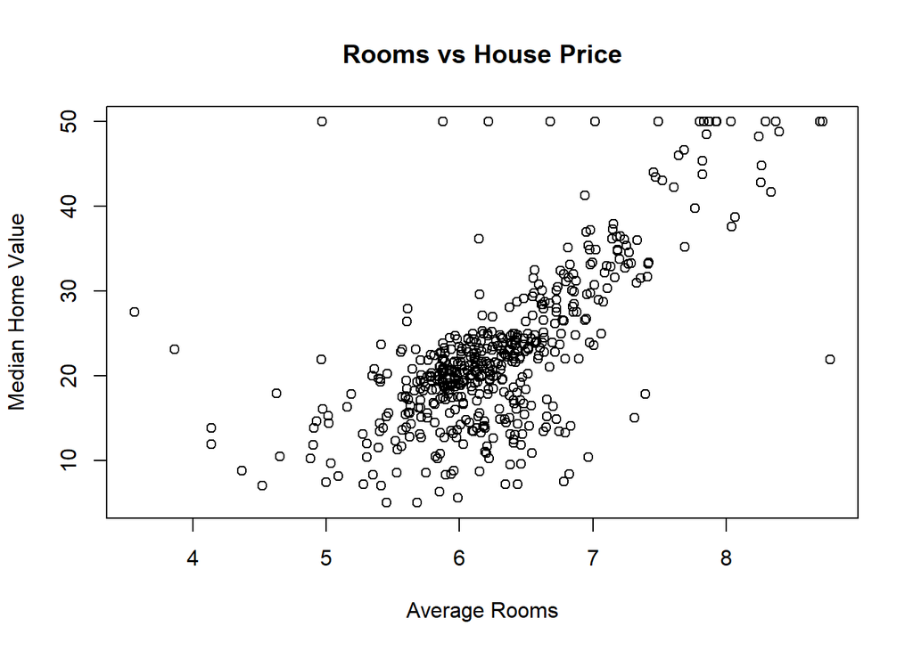

```r
plot(Boston$rm, Boston$medv,
     xlab = "Average Rooms",
     ylab = "Median Home Value",
     main = "Rooms vs House Price")
```

## 5. Fit a simple linear regression model predicting house price (medv) using number of rooms (rm)

```r
simpleBostonModel <- lm(medv ~ rm, data = Boston)
summary(simpleBostonModel)
```

```
##
## Call:
## lm(formula = medv ~ rm, data = Boston)
##
## Residuals:
##     Min      1Q  Median      3Q     Max
## -23.346  -2.547   0.090   2.986  39.433
##
## Coefficients:
##             Estimate Std. Error t value Pr(>|t|)
## (Intercept)  -34.671      2.650  -13.08   <2e-16 ***
## rm             9.102      0.419   21.72   <2e-16 ***
## ---
## Signif. codes:  0 '***' 0.001 '**' 0.01 '*' 0.05 '.' 0.1 ' ' 1
##
## Residual standard error: 6.616 on 504 degrees of freedom
## Multiple R-squared:  0.4835, Adjusted R-squared:  0.4825
## F-statistic: 471.8 on 1 and 504 DF,  p-value: < 2.2e-16
```

Model: y = -34.671 + 9.102x + E

With the given model, we can predict that the more rooms, the higher the house price will be. More specifically, the house price will increase by approximately $9,100, holding all other variables constant.

## 7. What percentage of variation in house price is explained by the model?

With the previous output, we can observe R-squared: 0.4835. About 48.35% of the variation in median house prices is explained by the number of rooms in the house.

## 8. Multiple linear regression. Fit a multiple linear regression model using rm, lstat, ptratio to predict medv

```r
multipleBostonModel <- lm(medv ~ rm + lstat + ptratio, data = Boston)
summary(multipleBostonModel)
```

```
##
## Call:
## lm(formula = medv ~ rm + lstat + ptratio, data = Boston)
##
## Residuals:
##      Min       1Q   Median       3Q      Max
## -14.4871  -3.1047  -0.7976   1.8129  29.6559
##
## Coefficients:
##             Estimate Std. Error t value Pr(>|t|)
## (Intercept) 18.56711    3.91320   4.745 2.73e-06 ***
## rm           4.51542    0.42587  10.603  < 2e-16 ***
## lstat       -0.57181    0.04223 -13.540  < 2e-16 ***
## ptratio     -0.93072    0.11765  -7.911 1.64e-14 ***
## ---
## Signif. codes:  0 '***' 0.001 '**' 0.01 '*' 0.05 '.' 0.1 ' ' 1
##
## Residual standard error: 5.229 on 502 degrees of freedom
## Multiple R-squared:  0.6786, Adjusted R-squared:  0.6767
## F-statistic: 353.3 on 3 and 502 DF,  p-value: < 2.2e-16
```

Model: y = 18.567 + 4.515x1 - 0.572x2 - 0.931x3 + E

- Each additional room is associated with a increase of $4,515 dollars in median home value.
- For a 1-unit increase in lstat (lower status of the population percentage), the median home value is expected to decrease by $572.
- For a 1-unit increase in ptratio (pupil-teacher ratio by town),, the median home value is expected to decrease by $931.

## 9. Which predictors are statistically significant?

All of the predictors are statistically significant, since their p-values are very much smaller than 0.05.

## 10. Compare both models

```r
summary(simpleBostonModel)
```

```
##
## Call:
## lm(formula = medv ~ rm, data = Boston)
##
## Residuals:
##     Min      1Q  Median      3Q     Max
## -23.346  -2.547   0.090   2.986  39.433
##
## Coefficients:
##             Estimate Std. Error t value Pr(>|t|)
## (Intercept)  -34.671      2.650  -13.08   <2e-16 ***
## rm             9.102      0.419   21.72   <2e-16 ***
## ---
## Signif. codes:  0 '***' 0.001 '**' 0.01 '*' 0.05 '.' 0.1 ' ' 1
##
## Residual standard error: 6.616 on 504 degrees of freedom
## Multiple R-squared:  0.4835, Adjusted R-squared:  0.4825
## F-statistic: 471.8 on 1 and 504 DF,  p-value: < 2.2e-16
```

```r
summary(multipleBostonModel)
```

```
##
## Call:
## lm(formula = medv ~ rm + lstat + ptratio, data = Boston)
##
## Residuals:
##      Min       1Q   Median       3Q      Max
## -14.4871  -3.1047  -0.7976   1.8129  29.6559
##
## Coefficients:
##             Estimate Std. Error t value Pr(>|t|)
## (Intercept) 18.56711    3.91320   4.745 2.73e-06 ***
## rm           4.51542    0.42587  10.603  < 2e-16 ***
## lstat       -0.57181    0.04223 -13.540  < 2e-16 ***
## ptratio     -0.93072    0.11765  -7.911 1.64e-14 ***
## ---
## Signif. codes:  0 '***' 0.001 '**' 0.01 '*' 0.05 '.' 0.1 ' ' 1
##
## Residual standard error: 5.229 on 502 degrees of freedom
## Multiple R-squared:  0.6786, Adjusted R-squared:  0.6767
## F-statistic: 353.3 on 3 and 502 DF,  p-value: < 2.2e-16
```

The multiple regression model has a higher Adjusted R-squared, as well as the addition of other significant predictors.

## 11. Check residual plots for multiple regression model

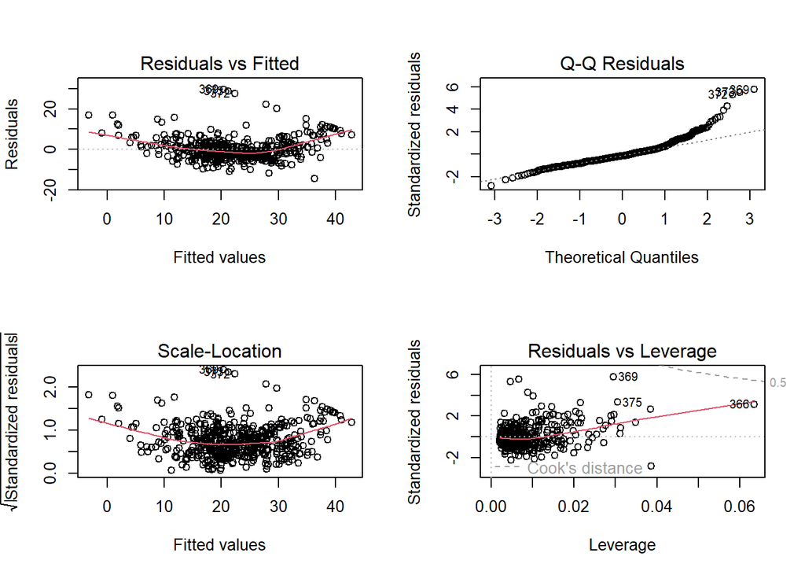

```r
par(mfrow = c(2,2))
plot(multipleBostonModel)
```

There is a clear violation in the linearity and constant variance assumptions.

## 12. Create confidence interval for regression coefficients

```r
confint(multipleBostonModel)
```

```
##                  2.5 %     97.5 %
## (Intercept) 10.8788409 26.2553821
## rm           3.6787108  5.3521311
## lstat       -0.6547754 -0.4888359
## ptratio     -1.1618769 -0.6995682
```

## 13. Check for multicollinearity using VIF

```r
vif(multipleBostonModel)
```

```
##       rm    lstat  ptratio
## 1.653419 1.679425 1.198101
```

The VIF for all variables is under our threshold of 10, so there is no risk of multicollinearity.

## 14. House price prediction

House: rm = 7, lstat = 10, ptratio = 18

```r
newHousePrediction <- data.frame(
  rm = 7,
  lstat = 10,
  ptratio = 18
)

predict(multipleBostonModel, newdata = newHousePrediction)
```

```
##      1
## 27.704
```

The predicted house value is $27,704.